# Entregable #3 - Exploratory Data Analysis in R

Primer paso: importar data frame

```r
df = read.csv("C:\\Users\\jap25\\OneDrive\\Documentos\\git workspace\\DataScienceCourseTasks\\Task #5 - Data Modeling with R\\Entregable 5\\fundamentals.csv", sep=",", header=TRUE)
dim(df)
```

```
[1] 1781   79
```

Segundo

```r
head(df)
```

|  | X | Ticker.Symbol | Period.Ending | Accounts.Payable | Accounts.Receivable | Add.l.income.expense.items | After.Tax.ROE | Capital.Expenditures | Capital.Surplus | Cash.Ratio | Cash.and.Cash.Equivalents | Changes.in.Inventories | Common.Stocks | Cost.of.Revenue | Current.Ratio | Deferred.Asset.Charges | Deferred.Liability.Charges | Depreciation | Earnings.Before.Interest.and.Tax | Earnings.Before.Tax | Effect.of.Exchange.Rate | Equity.Earnings.Loss.Unconsolidated.Subsidiary | Fixed.Assets | Goodwill | Gross.Margin | Gross.Profit | Income.Tax | Intangible.Assets | Interest.Expense | … |
| --- | --- | --- | --- | --- | --- | --- | --- | --- | --- | --- | --- | --- | --- | --- | --- | --- | --- | --- | --- | --- | --- | --- | --- | --- | --- | --- | --- | --- | --- | --- |
| 1 | 0 | AAL | 2012-12-31 | 3068000000 | -222000000 | -1.961e+09 | 23 | -1888000000 | 4695000000 | 53 | 1330000000 | 0 | 1.27e+08 | 10499000000 | 78 | 0.000e+00 | 2.23e+08 | 1001000000 | -1813000000 | -2445000000 | 0 | 0 | 13402000000 | 0 | 58 | 14356000000 | -569000000 | 869000000 | 632000000 | … |
| 2 | 1 | AAL | 2013-12-31 | 4975000000 | -93000000 | -2.723e+09 | 67 | -3114000000 | 10592000000 | 75 | 2175000000 | 0 | 5.00e+06 | 11019000000 | 104 | 0.000e+00 | 9.35e+08 | 1020000000 | -1324000000 | -2180000000 | 0 | 0 | 19259000000 | 4086000000 | 59 | 15724000000 | -346000000 | 2311000000 | 856000000 | … |
| 3 | 2 | AAL | 2014-12-31 | 4668000000 | -160000000 | -1.500e+08 | 143 | -5311000000 | 15135000000 | 60 | 1768000000 | 0 | 7.00e+06 | 15620000000 | 88 | 0.000e+00 | 8.29e+08 | 1342000000 | 4099000000 | 3212000000 | 0 | 0 | 23084000000 | 4091000000 | 63 | 27030000000 | 330000000 | 2240000000 | 887000000 | … |
| 4 | 3 | AAL | 2015-12-31 | 5102000000 | 352000000 | -7.080e+08 | 135 | -6151000000 | 11591000000 | 51 | 1085000000 | 0 | 6.00e+06 | 11096000000 | 73 | 2.477e+09 | 6.67e+08 | 1487000000 | 5496000000 | 4616000000 | 0 | 0 | 27510000000 | 4091000000 | 73 | 29894000000 | -2994000000 | 2249000000 | 880000000 | … |
| 5 | 4 | AAP | 2012-12-29 | 2409453000 | -89482000 | 6.000e+05 | 32 | -271182000 | 520215000 | 23 | 598111000 | -260298000 | 7.00e+03 | 3106967000 | 124 | 0.000e+00 | 0.00e+00 | 189544000 | 657915000 | 624074000 | 0 | 0 | 1292547000 | 76389000 | 50 | 3098036000 | 236404000 | 28845000 | 33841000 | … |
| 6 | 5 | AAP | 2013-12-28 | 2609239000 | -32428000 | 2.698e+06 | 26 | -195757000 | 531293000 | 40 | 1112471000 | -203513000 | 7.00e+03 | 3241668000 | 144 | 0.000e+00 | 0.00e+00 | 207795000 | 663016000 | 626398000 | 0 | 0 | 1286034000 | 199835000 | 50 | 3252146000 | 234640000 | 49872000 | 36618000 | … |

Procedemos a homologar y limpiar los nombres de las columnas quitando espacios en blanco innecesarios y los necesarios los cambiamos a “_”

```r
library(janitor)
df = clean_names(df)
head(df)
```

|  | x | ticker_symbol | period_ending | accounts_payable | accounts_receivable | add_l_income_expense_items | after_tax_roe | capital_expenditures | capital_surplus | cash_ratio | cash_and_cash_equivalents | changes_in_inventories | common_stocks | cost_of_revenue | current_ratio | deferred_asset_charges | deferred_liability_charges | depreciation | earnings_before_interest_and_tax | earnings_before_tax | effect_of_exchange_rate | equity_earnings_loss_unconsolidated_subsidiary | fixed_assets | goodwill | gross_margin | gross_profit | income_tax | intangible_assets | interest_expense | … |
| --- | --- | --- | --- | --- | --- | --- | --- | --- | --- | --- | --- | --- | --- | --- | --- | --- | --- | --- | --- | --- | --- | --- | --- | --- | --- | --- | --- | --- | --- | --- |
| 1 | 0 | AAL | 2012-12-31 | 3068000000 | -222000000 | -1.961e+09 | 23 | -1888000000 | 4695000000 | 53 | 1330000000 | 0 | 1.27e+08 | 10499000000 | 78 | 0.000e+00 | 2.23e+08 | 1001000000 | -1813000000 | -2445000000 | 0 | 0 | 13402000000 | 0 | 58 | 14356000000 | -569000000 | 869000000 | 632000000 | … |
| 2 | 1 | AAL | 2013-12-31 | 4975000000 | -93000000 | -2.723e+09 | 67 | -3114000000 | 10592000000 | 75 | 2175000000 | 0 | 5.00e+06 | 11019000000 | 104 | 0.000e+00 | 9.35e+08 | 1020000000 | -1324000000 | -2180000000 | 0 | 0 | 19259000000 | 4086000000 | 59 | 15724000000 | -346000000 | 2311000000 | 856000000 | … |
| 3 | 2 | AAL | 2014-12-31 | 4668000000 | -160000000 | -1.500e+08 | 143 | -5311000000 | 15135000000 | 60 | 1768000000 | 0 | 7.00e+06 | 15620000000 | 88 | 0.000e+00 | 8.29e+08 | 1342000000 | 4099000000 | 3212000000 | 0 | 0 | 23084000000 | 4091000000 | 63 | 27030000000 | 330000000 | 2240000000 | 887000000 | … |
| 4 | 3 | AAL | 2015-12-31 | 5102000000 | 352000000 | -7.080e+08 | 135 | -6151000000 | 11591000000 | 51 | 1085000000 | 0 | 6.00e+06 | 11096000000 | 73 | 2.477e+09 | 6.67e+08 | 1487000000 | 5496000000 | 4616000000 | 0 | 0 | 27510000000 | 4091000000 | 73 | 29894000000 | -2994000000 | 2249000000 | 880000000 | … |
| 5 | 4 | AAP | 2012-12-29 | 2409453000 | -89482000 | 6.000e+05 | 32 | -271182000 | 520215000 | 23 | 598111000 | -260298000 | 7.00e+03 | 3106967000 | 124 | 0.000e+00 | 0.00e+00 | 189544000 | 657915000 | 624074000 | 0 | 0 | 1292547000 | 76389000 | 50 | 3098036000 | 236404000 | 28845000 | 33841000 | … |
| 6 | 5 | AAP | 2013-12-28 | 2609239000 | -32428000 | 2.698e+06 | 26 | -195757000 | 531293000 | 40 | 1112471000 | -203513000 | 7.00e+03 | 3241668000 | 144 | 0.000e+00 | 0.00e+00 | 207795000 | 663016000 | 626398000 | 0 | 0 | 1286034000 | 199835000 | 50 | 3252146000 | 234640000 | 49872000 | 36618000 | … |

Convertimos columna de fecha a tipo fecha

```r
df$period_ending <- as.Date(df$period_ending, format = "%Y-%m-%d")
```

Tal y como se hizo en el ejercicio anterior, iteramos entre las columnas para hacer la limpieza correspondiente de cada una

```r
string_columns <- sapply(df, is.character)

df[string_columns] <- lapply(df[string_columns], function(col) {
  col <- trimws(col) # Elimina espacios al inicio y al final
  col <- tolower(col) # Convierte a minúsculas
  return(col)
})
```

Verificamos los tipos de datos de las columnas para ver si está acorde a lo que necesitamos

```r
str(df)
```

```
'data.frame':   1781 obs. of  79 variables:
 $ x                                                : int  0 1 2 3 4 5 6 7 8 9 ...
 $ ticker_symbol                                    : chr  "aal" "aal" "aal" "aal" ...
 $ period_ending                                    : Date, format: "2012-12-31" "2013-12-31" "2014-12-31" ...
 $ accounts_payable                                 : num  3.07e+09 4.98e+09 4.67e+09 5.10e+09 2.41e+09 ...
 $ accounts_receivable                              : num  -2.22e+08 -9.30e+07 -1.60e+08 3.52e+08 -8.95e+07 ...
 $ add_l_income_expense_items                       : num  -1.96e+09 -2.72e+09 -1.50e+08 -7.08e+08 6.00e+05 ...
 $ after_tax_roe                                    : num  23 67 143 135 32 26 25 19 30 35 ...
 $ capital_expenditures                             : num  -1.89e+09 -3.11e+09 -5.31e+09 -6.15e+09 -2.71e+08 ...
 $ capital_surplus                                  : num  4.70e+09 1.06e+10 1.51e+10 1.16e+10 5.20e+08 ...
 $ cash_ratio                                       : num  53 75 60 51 23 40 3 2 93 40 ...
 $ cash_and_cash_equivalents                        : num  1.33e+09 2.18e+09 1.77e+09 1.08e+09 5.98e+08 ...
 $ changes_in_inventories                           : num  0.0 0.0 0.0 0.0 -2.6e+08 ...
 $ common_stocks                                    : num  1.27e+08 5.00e+06 7.00e+06 6.00e+06 7.00e+03 ...
 $ cost_of_revenue                                  : num  1.05e+10 1.10e+10 1.56e+10 1.11e+10 3.11e+09 ...
```

[output cut: 65 more lines]

En este punto podremos definir a que se refiere cada columna: Ticker Symbol: Símbolo de Cotización Period Ending: Fin del Período Accounts Payable: Cuentas por Pagar Accounts Receivable: Cuentas por Cobrar Add’l income/expense items: Elementos Adicionales de Ingresos/Gastos After Tax ROE: ROE después de Impuestos (Retorno sobre el Capital) Capital Expenditures: Gastos de Capital Capital Surplus: Superávit de Capital Cash Ratio: Ratio de Liquidez Cash and Cash Equivalents: Efectivo y Equivalentes de Efectivo Changes in Inventories: Cambios en Inventarios Common Stocks: Acciones Comunes Cost of Revenue: Costo de Ingresos Current Ratio: Ratio de Liquidez Corriente Deferred Asset Charges: Cargos por Activos Diferidos Deferred Liability Charges: Cargos por Pasivos Diferidos Depreciation: Depreciación Earnings Before Interest and Tax: Ganancias antes de Intereses e Impuestos Earnings Before Tax: Ganancias antes de Impuestos Effect of Exchange Rate: Efecto del Tipo de Cambio Equity Earnings/Loss Unconsolidated Subsidiary: Ganancias/Pérdidas de Capital de Filial No Consolidada Fixed Assets: Activos Fijos Goodwill: Fondo de Comercio Gross Margin: Margen Bruto Gross Profit: Beneficio Bruto Income Tax: Impuesto sobre la Renta Intangible Assets: Activos Intangibles Interest Expense: Gastos por Intereses Inventory: Inventario Investments: Inversiones Liabilities: Pasivos Long-Term Debt: Deuda a Largo Plazo Long-Term Investments: Inversiones a Largo Plazo Minority Interest: Interés Minoritario Misc. Stocks: Acciones Diversas Net Borrowings: Préstamos Netos Net Cash Flow: Flujo de Caja Neto Net Cash Flow-Operating: Flujo de Caja Neto de Operaciones Net Cash Flows-Financing: Flujos de Caja Netos de Financiamiento Net Cash Flows-Investing: Flujos de Caja Netos de Inversión Net Income: Ingreso Neto Net Income Adjustments: Ajustes al Ingreso Neto Net Income Applicable to Common Shareholders: Ingreso Neto Aplicable a Accionistas Comunes Net Income-Cont. Operations: Ingreso Neto de Operaciones Continuas Net Receivables: Cuentas por Cobrar Netas Non-Recurring Items: Elementos No Recurrentes Operating Income: Ingreso Operativo Operating Margin: Margen Operativo Other Assets: Otros Activos Other Current Assets: Otros Activos Corrientes Other Current Liabilities: Otras Pasivos Corrientes Other Equity: Otras Participaciones en el Capital Other Financing Activities: Otras Actividades de Financiamiento Other Investing Activities: Otras Actividades de Inversión Other Liabilities: Otros Pasivos Other Operating Activities: Otras Actividades Operativas Other Operating Items: Otros Elementos Operativos Pre-Tax Margin: Margen antes de Impuestos Pre-Tax ROE: ROE antes de Impuestos Profit Margin: Margen de Beneficio Quick Ratio: Ratio de Prueba Ácida Research and Development: Investigación y Desarrollo Retained Earnings: Ganancias Retenidas Sale and Purchase of Stock: Venta y Compra de Acciones Sales, General and Admin.: Ventas, General y Administración Short-Term Debt / Current Portion of Long-Term Debt: Deuda a Corto Plazo / Porción Corriente de la Deuda a Largo Plazo Short-Term Investments: Inversiones a Corto Plazo Total Assets: Activos Totales Total Current Assets: Activos Corrientes Totales Total Current Liabilities: Pasivos Corrientes Totales Total Equity: Patrimonio Total Total Liabilities: Pasivos Totales Total Liabilities & Equity: Total de Pasivos y Patrimonio Total Revenue: Ingresos Totales Treasury Stock: Acciones de Tesorería For Year: Para el Año Earnings Per Share: Ganancias por Acción Estimated Shares Outstanding: Acciones Estimadas en Circulación

E identificamos como variables objetivo: Para el siguiente ejercicio identifico como importante el margen de beneficio neto, lo cual, se calcula dividiendo el ingreso neto entre los ingresos totales, por ende, nuestras dos variables objetivos serían:

- Total Revenue (Ingresos Totales): Una variable clave para el análisis fundamental, los ingresos totales pueden indicar la salud general y la tendencia de crecimiento de una empresa. Analizar cómo los ingresos afectan los precios de las acciones podría ser crucial para comprender si la negociación automatizada puede identificar oportunidades de inversión basadas en el crecimiento de ingresos.
- Net Income (Ingreso Neto): Representa las ganancias totales después de deducir gastos e impuestos. Esta variable es un indicador significativo del éxito financiero de una empresa y puede ser vital para entender cómo las máquinas interpretan y reaccionan a los cambios en la rentabilidad.

Verificamos que las variables Net Income y Total Revenue no tengan vacíos que eviten la correcta implementación de los cálculos

```r
print(colSums(is.na(df)))
```

```
                                                x                                     ticker_symbol
                                                0                                                 0
                                    period_ending                                  accounts_payable
                                                0                                                 0
                              accounts_receivable                        add_l_income_expense_items
                                                0                                                 0
                                    after_tax_roe                              capital_expenditures
                                                0                                                 0
                                  capital_surplus                                        cash_ratio
                                                0                                               299
                        cash_and_cash_equivalents                            changes_in_inventories
                                                0                                                 0
                                    common_stocks                                   cost_of_revenue
                                                0                                                 0
                                    current_ratio                            deferred_asset_charges
                                              299                                                 0
                       deferred_liability_charges                                      depreciation
                                                0                                                 0
                 earnings_before_interest_and_tax                               earnings_before_tax
                                                0                                                 0
                          effect_of_exchange_rate    equity_earnings_loss_unconsolidated_subsidiary
                                                0                                                 0
                                     fixed_assets                                          goodwill
                                                0                                                 0
                                     gross_margin                                      gross_profit
                                                0                                                 0
                                       income_tax                                 intangible_assets
                                                0                                                 0
                                 interest_expense                                         inventory
                                                0                                                 0
                                      investments                                       liabilities
                                                0                                                 0
                                   long_term_debt                             long_term_investments
                                                0                                                 0
                                minority_interest                                       misc_stocks
                                                0                                                 0
                                   net_borrowings                                     net_cash_flow
                                                0                                                 0
                          net_cash_flow_operating                          net_cash_flows_financing
                                                0                                                 0
```

[output cut: 25 more lines]

```
                                                0                                                 0
short_term_debt_current_portion_of_long_term_debt                            short_term_investments
                                                0                                                 0
                                     total_assets                              total_current_assets
                                                0                                                 0
                        total_current_liabilities                                      total_equity
                                                0                                                 0
                                total_liabilities                          total_liabilities_equity
                                                0                                                 0
                                    total_revenue                                    treasury_stock
                                                0                                                 0
                                         for_year                                earnings_per_share
                                              173                                               219
                     estimated_shares_outstanding
                                              219
```

Ya verificado que las variables a utilizar para crear nuestra variable objetivo están en completo orden, procedemos a crear nuestra variable objetivo: BeneficioNeto

```r
df$beneficioNeto <- df$net_income / df$total_revenue
head(df)
```

|  | x | ticker_symbol | period_ending | accounts_payable | accounts_receivable | add_l_income_expense_items | after_tax_roe | capital_expenditures | capital_surplus | cash_ratio | cash_and_cash_equivalents | changes_in_inventories | common_stocks | cost_of_revenue | current_ratio | deferred_asset_charges | deferred_liability_charges | depreciation | earnings_before_interest_and_tax | earnings_before_tax | effect_of_exchange_rate | equity_earnings_loss_unconsolidated_subsidiary | fixed_assets | goodwill | gross_margin | gross_profit | income_tax | intangible_assets | interest_expense | … |
| --- | --- | --- | --- | --- | --- | --- | --- | --- | --- | --- | --- | --- | --- | --- | --- | --- | --- | --- | --- | --- | --- | --- | --- | --- | --- | --- | --- | --- | --- | --- |
| 1 | 0 | aal | 2012-12-31 | 3068000000 | -222000000 | -1.961e+09 | 23 | -1888000000 | 4695000000 | 53 | 1330000000 | 0 | 1.27e+08 | 10499000000 | 78 | 0.000e+00 | 2.23e+08 | 1001000000 | -1813000000 | -2445000000 | 0 | 0 | 13402000000 | 0 | 58 | 14356000000 | -569000000 | 869000000 | 632000000 | … |
| 2 | 1 | aal | 2013-12-31 | 4975000000 | -93000000 | -2.723e+09 | 67 | -3114000000 | 10592000000 | 75 | 2175000000 | 0 | 5.00e+06 | 11019000000 | 104 | 0.000e+00 | 9.35e+08 | 1020000000 | -1324000000 | -2180000000 | 0 | 0 | 19259000000 | 4086000000 | 59 | 15724000000 | -346000000 | 2311000000 | 856000000 | … |
| 3 | 2 | aal | 2014-12-31 | 4668000000 | -160000000 | -1.500e+08 | 143 | -5311000000 | 15135000000 | 60 | 1768000000 | 0 | 7.00e+06 | 15620000000 | 88 | 0.000e+00 | 8.29e+08 | 1342000000 | 4099000000 | 3212000000 | 0 | 0 | 23084000000 | 4091000000 | 63 | 27030000000 | 330000000 | 2240000000 | 887000000 | … |
| 4 | 3 | aal | 2015-12-31 | 5102000000 | 352000000 | -7.080e+08 | 135 | -6151000000 | 11591000000 | 51 | 1085000000 | 0 | 6.00e+06 | 11096000000 | 73 | 2.477e+09 | 6.67e+08 | 1487000000 | 5496000000 | 4616000000 | 0 | 0 | 27510000000 | 4091000000 | 73 | 29894000000 | -2994000000 | 2249000000 | 880000000 | … |
| 5 | 4 | aap | 2012-12-29 | 2409453000 | -89482000 | 6.000e+05 | 32 | -271182000 | 520215000 | 23 | 598111000 | -260298000 | 7.00e+03 | 3106967000 | 124 | 0.000e+00 | 0.00e+00 | 189544000 | 657915000 | 624074000 | 0 | 0 | 1292547000 | 76389000 | 50 | 3098036000 | 236404000 | 28845000 | 33841000 | … |
| 6 | 5 | aap | 2013-12-28 | 2609239000 | -32428000 | 2.698e+06 | 26 | -195757000 | 531293000 | 40 | 1112471000 | -203513000 | 7.00e+03 | 3241668000 | 144 | 0.000e+00 | 0.00e+00 | 207795000 | 663016000 | 626398000 | 0 | 0 | 1286034000 | 199835000 | 50 | 3252146000 | 234640000 | 49872000 | 36618000 | … |

Verificamos que la variable creada no tenga registros en blanco

```r
print(colSums(is.na(df)))
```

```
                                                x                                     ticker_symbol
                                                0                                                 0
                                    period_ending                                  accounts_payable
                                                0                                                 0
                              accounts_receivable                        add_l_income_expense_items
                                                0                                                 0
                                    after_tax_roe                              capital_expenditures
                                                0                                                 0
                                  capital_surplus                                        cash_ratio
                                                0                                               299
                        cash_and_cash_equivalents                            changes_in_inventories
                                                0                                                 0
                                    common_stocks                                   cost_of_revenue
                                                0                                                 0
                                    current_ratio                            deferred_asset_charges
                                              299                                                 0
                       deferred_liability_charges                                      depreciation
                                                0                                                 0
                 earnings_before_interest_and_tax                               earnings_before_tax
                                                0                                                 0
                          effect_of_exchange_rate    equity_earnings_loss_unconsolidated_subsidiary
                                                0                                                 0
                                     fixed_assets                                          goodwill
                                                0                                                 0
                                     gross_margin                                      gross_profit
                                                0                                                 0
                                       income_tax                                 intangible_assets
                                                0                                                 0
                                 interest_expense                                         inventory
                                                0                                                 0
                                      investments                                       liabilities
                                                0                                                 0
                                   long_term_debt                             long_term_investments
                                                0                                                 0
                                minority_interest                                       misc_stocks
                                                0                                                 0
                                   net_borrowings                                     net_cash_flow
                                                0                                                 0
                          net_cash_flow_operating                          net_cash_flows_financing
                                                0                                                 0
```

[output cut: 25 more lines]

```
                                                0                                                 0
short_term_debt_current_portion_of_long_term_debt                            short_term_investments
                                                0                                                 0
                                     total_assets                              total_current_assets
                                                0                                                 0
                        total_current_liabilities                                      total_equity
                                                0                                                 0
                                total_liabilities                          total_liabilities_equity
                                                0                                                 0
                                    total_revenue                                    treasury_stock
                                                0                                                 0
                                         for_year                                earnings_per_share
                                              173                                               219
                     estimated_shares_outstanding                                     beneficioNeto
                                              219                                                 0
```

Una vez verificado que todo está en perfecto orden, procedemos a graficar nuestra variable objetivo

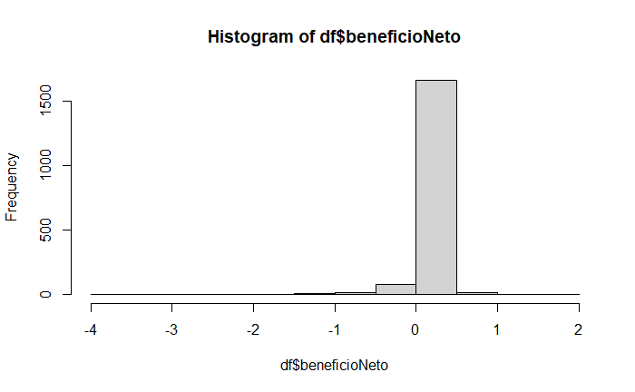

```r
hist(df$beneficioNeto, freq = TRUE)
```

Procedemos a normalizar utilizando la técnica de normalización por variación y graficamos nuevamente para observar el cambio

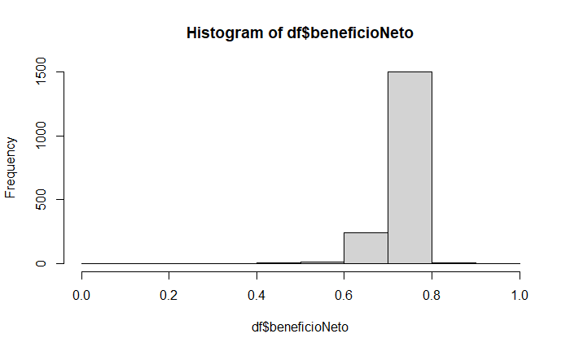

```r
min_val <- min(df$beneficioNeto)
max_val <- max(df$beneficioNeto)
df$beneficioNeto <- (df$beneficioNeto - min_val) / (max_val - min_val)
hist(df$beneficioNeto, freq = TRUE)
```

Verificamos nuevamente que no existan nulos en la variable objetivo

```r
print(colSums(is.na(df)))
```

```
                                                x                                     ticker_symbol
                                                0                                                 0
                                    period_ending                                  accounts_payable
                                                0                                                 0
                              accounts_receivable                        add_l_income_expense_items
                                                0                                                 0
                                    after_tax_roe                              capital_expenditures
                                                0                                                 0
                                  capital_surplus                                        cash_ratio
                                                0                                               299
                        cash_and_cash_equivalents                            changes_in_inventories
                                                0                                                 0
                                    common_stocks                                   cost_of_revenue
                                                0                                                 0
                                    current_ratio                            deferred_asset_charges
                                              299                                                 0
                       deferred_liability_charges                                      depreciation
                                                0                                                 0
                 earnings_before_interest_and_tax                               earnings_before_tax
                                                0                                                 0
                          effect_of_exchange_rate    equity_earnings_loss_unconsolidated_subsidiary
                                                0                                                 0
                                     fixed_assets                                          goodwill
                                                0                                                 0
                                     gross_margin                                      gross_profit
                                                0                                                 0
                                       income_tax                                 intangible_assets
                                                0                                                 0
                                 interest_expense                                         inventory
                                                0                                                 0
                                      investments                                       liabilities
                                                0                                                 0
                                   long_term_debt                             long_term_investments
                                                0                                                 0
                                minority_interest                                       misc_stocks
                                                0                                                 0
                                   net_borrowings                                     net_cash_flow
                                                0                                                 0
                          net_cash_flow_operating                          net_cash_flows_financing
                                                0                                                 0
```

[output cut: 25 more lines]

```
                                                0                                                 0
short_term_debt_current_portion_of_long_term_debt                            short_term_investments
                                                0                                                 0
                                     total_assets                              total_current_assets
                                                0                                                 0
                        total_current_liabilities                                      total_equity
                                                0                                                 0
                                total_liabilities                          total_liabilities_equity
                                                0                                                 0
                                    total_revenue                                    treasury_stock
                                                0                                                 0
                                         for_year                                earnings_per_share
                                              173                                               219
                     estimated_shares_outstanding                                     beneficioNeto
                                              219                                                 0
```

Dividimos los datos en 3 con las siguientes proporciones: 60% Valores de entrenamiento 20% Valores de prueba 20% Valores de Validación Y revisamos el set de datos de entrenamiento también

```r
trvaltest <- function(dat,prop = c(0.6,0.2,0.2)){
  nrw = nrow(dat) #Define la cantidad de filas
  trnr = as.integer(nrw *prop[1]) #Obtiene la fila que se encuentra en el 60% de la data
  vlnr = as.integer(nrw*prop[2]) #Obtiene la fila que se encuentra en el 20% del restante de la data
  set.seed(123) #Crea la semilla para crear números aleatorios
  trni = sample(1:nrow(dat),trnr) #Crea vector con índices que conformará el set de datos de entrenamiento
  trndata = dat[trni,] #Crea el Dataframe de entrenamiento
  rmng = dat[-trni,] # Crea nuevo datafram con todos los índices menos los elegidos para trni
  vlni = sample(1:nrow(rmng),vlnr) #Define los índices para el dataframe de validación y prueba
  valdata = rmng[vlni,] #Crea Dataframe de validación con los índices de vlni
  tstdata = rmng[-vlni,] ##Crea Dataframe de validación con los índices que no están en vlni
  mylist = list("trn" = trndata,"val"= valdata,"tst" = tstdata) #Crea una lista de dataframes con los 3 creados.
  return(mylist)
}

outdata = trvaltest(df,prop = c(0.6,0.2,0.2))
df_train = outdata$trn; df_val = outdata$val; df_test = outdata$tst

head(df_train)
```

|  | x | ticker_symbol | period_ending | accounts_payable | accounts_receivable | add_l_income_expense_items | after_tax_roe | capital_expenditures | capital_surplus | cash_ratio | cash_and_cash_equivalents | changes_in_inventories | common_stocks | cost_of_revenue | current_ratio | deferred_asset_charges | deferred_liability_charges | depreciation | earnings_before_interest_and_tax | earnings_before_tax | effect_of_exchange_rate | equity_earnings_loss_unconsolidated_subsidiary | fixed_assets | goodwill | gross_margin | gross_profit | income_tax | intangible_assets | interest_expense | … |
| --- | --- | --- | --- | --- | --- | --- | --- | --- | --- | --- | --- | --- | --- | --- | --- | --- | --- | --- | --- | --- | --- | --- | --- | --- | --- | --- | --- | --- | --- | --- |
| 415 | 414 | ctxs | 2015-12-31 | 431215000 | -7226000 | 5945000 | 16 | -160825000 | 4566919000 | 52 | 368518000 | 7.03e+05 | 299000 | 614364000 | 100 | 215196000 | 414314000 | 428892000 | 356030000 | 311877000 | -10313000 | 0 | 373817000 | 1962722000 | 81 | 2661230000 | -7484000 | 283418000 | 44153000 | … |
| 463 | 462 | dhr | 2014-12-31 | 5016500000 | -113400000 | 173200000 | 11 | -580600000 | 4480900000 | 56 | 3005600000 | 4.99e+07 | 7900000 | 9261400000 | 175 | 0 | 0 | 889500000 | 3519800000 | 3400700000 | -205500000 | 0 | 2171900000 | 15673200000 | 52 | 9892600000 | 857600000 | 7059500000 | 119100000 | … |
| 179 | 178 | ayi | 2013-08-31 | 386200000 | -54800000 | 2800000 | 13 | -40600000 | 735500000 | 93 | 359100000 | -6.50e+06 | 500000 | 1251500000 | 237 | 1700000 | 53900000 | 40800000 | 224300000 | 193100000 | -300000 | 0 | 147900000 | 568200000 | 40 | 837600000 | 65700000 | 245100000 | 31200000 | … |
| 526 | 525 | ecl | 2013-12-31 | 1673900000 | -147400000 | 0 | 13 | -625100000 | 4692000000 | 10 | 339200000 | -3.05e+07 | 345100000 | 7161200000 | 135 | 0 | 0 | 816200000 | 1560600000 | 1298300000 | 1900000 | 0 | 2882000000 | 6862900000 | 46 | 6092200000 | 324700000 | 4785300000 | 262300000 | … |
| 195 | 194 | bax | 2012-12-31 | 4409000000 | -41000000 | 155000000 | 34 | -1161000000 | 5769000000 | 69 | 3270000000 | -1.29e+08 | 683000000 | 6802000000 | 195 | 0 | 0 | 712000000 | 2925000000 | 2838000000 | -57000000 | 0 | 6098000000 | 2502000000 | 51 | 7134000000 | 555000000 | 814000000 | 87000000 | … |
| 938 | 937 | ksu | 2015-12-31 | 401500000 | 12000000 | -67600000 | 12 | -832200000 | 947100000 | 18 | 136600000 | -2.62e+07 | 1100000 | 759200000 | 71 | 0 | 1191100000 | 284600000 | 754500000 | 672600000 | 0 | 18300000 | 7705400000 | 0 | 69 | 1659600000 | 187300000 | 0 | 81900000 | … |

Revisamos el set de datos de entrenamiento

```r
head(df_train)
```

|  | x | ticker_symbol | period_ending | accounts_payable | accounts_receivable | add_l_income_expense_items | after_tax_roe | capital_expenditures | capital_surplus | cash_ratio | cash_and_cash_equivalents | changes_in_inventories | common_stocks | cost_of_revenue | current_ratio | deferred_asset_charges | deferred_liability_charges | depreciation | earnings_before_interest_and_tax | earnings_before_tax | effect_of_exchange_rate | equity_earnings_loss_unconsolidated_subsidiary | fixed_assets | goodwill | gross_margin | gross_profit | income_tax | intangible_assets | interest_expense | … |
| --- | --- | --- | --- | --- | --- | --- | --- | --- | --- | --- | --- | --- | --- | --- | --- | --- | --- | --- | --- | --- | --- | --- | --- | --- | --- | --- | --- | --- | --- | --- |
| 415 | 414 | ctxs | 2015-12-31 | 431215000 | -7226000 | 5945000 | 16 | -160825000 | 4566919000 | 52 | 368518000 | 7.03e+05 | 299000 | 614364000 | 100 | 215196000 | 414314000 | 428892000 | 356030000 | 311877000 | -10313000 | 0 | 373817000 | 1962722000 | 81 | 2661230000 | -7484000 | 283418000 | 44153000 | … |
| 463 | 462 | dhr | 2014-12-31 | 5016500000 | -113400000 | 173200000 | 11 | -580600000 | 4480900000 | 56 | 3005600000 | 4.99e+07 | 7900000 | 9261400000 | 175 | 0 | 0 | 889500000 | 3519800000 | 3400700000 | -205500000 | 0 | 2171900000 | 15673200000 | 52 | 9892600000 | 857600000 | 7059500000 | 119100000 | … |
| 179 | 178 | ayi | 2013-08-31 | 386200000 | -54800000 | 2800000 | 13 | -40600000 | 735500000 | 93 | 359100000 | -6.50e+06 | 500000 | 1251500000 | 237 | 1700000 | 53900000 | 40800000 | 224300000 | 193100000 | -300000 | 0 | 147900000 | 568200000 | 40 | 837600000 | 65700000 | 245100000 | 31200000 | … |
| 526 | 525 | ecl | 2013-12-31 | 1673900000 | -147400000 | 0 | 13 | -625100000 | 4692000000 | 10 | 339200000 | -3.05e+07 | 345100000 | 7161200000 | 135 | 0 | 0 | 816200000 | 1560600000 | 1298300000 | 1900000 | 0 | 2882000000 | 6862900000 | 46 | 6092200000 | 324700000 | 4785300000 | 262300000 | … |
| 195 | 194 | bax | 2012-12-31 | 4409000000 | -41000000 | 155000000 | 34 | -1161000000 | 5769000000 | 69 | 3270000000 | -1.29e+08 | 683000000 | 6802000000 | 195 | 0 | 0 | 712000000 | 2925000000 | 2838000000 | -57000000 | 0 | 6098000000 | 2502000000 | 51 | 7134000000 | 555000000 | 814000000 | 87000000 | … |
| 938 | 937 | ksu | 2015-12-31 | 401500000 | 12000000 | -67600000 | 12 | -832200000 | 947100000 | 18 | 136600000 | -2.62e+07 | 1100000 | 759200000 | 71 | 0 | 1191100000 | 284600000 | 754500000 | 672600000 | 0 | 18300000 | 7705400000 | 0 | 69 | 1659600000 | 187300000 | 0 | 81900000 | … |

Revisamos el set de datos de validación

```r
head(df_val)
```

|  | x | ticker_symbol | period_ending | accounts_payable | accounts_receivable | add_l_income_expense_items | after_tax_roe | capital_expenditures | capital_surplus | cash_ratio | cash_and_cash_equivalents | changes_in_inventories | common_stocks | cost_of_revenue | current_ratio | deferred_asset_charges | deferred_liability_charges | depreciation | earnings_before_interest_and_tax | earnings_before_tax | effect_of_exchange_rate | equity_earnings_loss_unconsolidated_subsidiary | fixed_assets | goodwill | gross_margin | gross_profit | income_tax | intangible_assets | interest_expense | … |
| --- | --- | --- | --- | --- | --- | --- | --- | --- | --- | --- | --- | --- | --- | --- | --- | --- | --- | --- | --- | --- | --- | --- | --- | --- | --- | --- | --- | --- | --- | --- |
| 550 | 549 | emr | 2014-09-30 | 5.98900e+09 | 163000000 | 0 | 22 | -6.510e+08 | 1.610e+08 | 37 | 3.1490e+09 | 1.03e+08 | 4.770e+08 | 9.9710e+09 | 129 | 0.000e+00 | 0.000e+00 | 5.690e+08 | 3.3870e+09 | 3.1910e+09 | -1.00e+08 | 0 | 3.8020e+09 | 7.1820e+09 | 44 | 7.7620e+09 | 9.53e+08 | 1.689e+09 | 1.960e+08 | … |
| 113 | 112 | amp | 2012-12-31 | 1.32400e+09 | -130000000 | 0 | 11 | -1.370e+08 | 6.503e+09 | NA | 4.9090e+09 | 0.00e+00 | 3.000e+06 | 1.8990e+09 | NA | 2.399e+09 | 0.000e+00 | 2.250e+08 | 1.5560e+09 | 1.2380e+09 | 1.00e+07 | 0 | 0.0000e+00 | 0.0000e+00 | 81 | 8.3600e+09 | 3.35e+08 | 0.000e+00 | 3.180e+08 | … |
| 632 | 631 | fdx | 2016-05-31 | 7.97900e+09 | -199000000 | -1000000 | 13 | -4.818e+09 | 2.892e+09 | 44 | 3.5340e+09 | 0.00e+00 | 3.200e+07 | 1.7327e+10 | 150 | 0.000e+00 | 2.122e+09 | 2.631e+09 | 3.0760e+09 | 2.7400e+09 | -1.02e+08 | 0 | 2.4284e+10 | 6.7470e+09 | 66 | 3.3038e+10 | 9.20e+08 | 0.000e+00 | 3.360e+08 | … |
| 845 | 844 | intu | 2014-07-31 | 4.07000e+08 | -5000000 | 31000000 | 29 | -1.040e+08 | 3.558e+09 | 135 | 8.4900e+08 | 0.00e+00 | 3.000e+06 | 6.0300e+08 | 184 | 0.000e+00 | 3.000e+06 | 1.970e+08 | 1.3310e+09 | 1.3000e+09 | -6.00e+06 | 0 | 5.8900e+08 | 1.3230e+09 | 86 | 3.6400e+09 | 4.47e+08 | 1.330e+08 | 3.100e+07 | … |
| 887 | 886 | jpm | 2015-12-31 | 1.77638e+11 | 22664000000 | 0 | 10 | 0.000e+00 | 9.250e+10 | NA | 5.7308e+11 | 0.00e+00 | 4.105e+09 | 0.0000e+00 | NA | 0.000e+00 | 0.000e+00 | 4.940e+09 | 3.8165e+10 | 3.0702e+10 | -2.76e+08 | 0 | 1.4362e+10 | 4.7325e+10 | 100 | 8.9716e+10 | 6.26e+09 | 7.623e+09 | 7.463e+09 | … |
| 85 | 84 | all | 2012-12-31 | 0.00000e+00 | -1685000000 | 18000000 | 11 | -2.850e+08 | 3.162e+09 | NA | 8.0600e+08 | 0.00e+00 | 9.000e+06 | 2.1618e+10 | NA | 3.621e+09 | 5.970e+08 | 3.880e+08 | 3.6790e+09 | 3.3060e+09 | 0.00e+00 | 0 | 9.8900e+08 | 1.2400e+09 | 35 | 1.1697e+10 | 1.00e+09 | 0.000e+00 | 3.730e+08 | … |

Revisamos el set de datos de prueba

```r
head(df_test)
```

|  | x | ticker_symbol | period_ending | accounts_payable | accounts_receivable | add_l_income_expense_items | after_tax_roe | capital_expenditures | capital_surplus | cash_ratio | cash_and_cash_equivalents | changes_in_inventories | common_stocks | cost_of_revenue | current_ratio | deferred_asset_charges | deferred_liability_charges | depreciation | earnings_before_interest_and_tax | earnings_before_tax | effect_of_exchange_rate | equity_earnings_loss_unconsolidated_subsidiary | fixed_assets | goodwill | gross_margin | gross_profit | income_tax | intangible_assets | interest_expense | … |
| --- | --- | --- | --- | --- | --- | --- | --- | --- | --- | --- | --- | --- | --- | --- | --- | --- | --- | --- | --- | --- | --- | --- | --- | --- | --- | --- | --- | --- | --- | --- |
| 3 | 2 | aal | 2014-12-31 | 4668000000 | -160000000 | -1.500e+08 | 143 | -5311000000 | 15135000000 | 60 | 1768000000 | 0 | 7.0000e+06 | 15620000000 | 88 | 0.000e+00 | 829000000 | 1342000000 | 4099000000 | 3212000000 | 0 | 0 | 23084000000 | 4091000000 | 63 | 27030000000 | 330000000 | 2240000000 | 887000000 | … |
| 7 | 6 | aap | 2015-01-03 | 3616038000 | -48209000 | 3.092e+06 | 25 | -228446000 | 562945000 | 3 | 104671000 | -227657000 | 7.0000e+03 | 5390248000 | 130 | 0.000e+00 | 446351000 | 284693000 | 854802000 | 781394000 | -4465000 | 0 | 1432030000 | 995426000 | 45 | 4453613000 | 287569000 | 748125000 | 73408000 | … |
| 14 | 13 | abbv | 2013-12-31 | 6448000000 | 681000000 | -5.400e+07 | 92 | -491000000 | 3671000000 | 144 | 9595000000 | -56000000 | 1.6000e+07 | 4581000000 | 259 | 0.000e+00 | 0 | 897000000 | 5610000000 | 5332000000 | -10000000 | 0 | 2298000000 | 6277000000 | 76 | 14209000000 | 1204000000 | 1890000000 | 278000000 | … |
| 15 | 14 | abbv | 2014-12-31 | 6954000000 | -172000000 | -6.510e+08 | 102 | -612000000 | 4194000000 | 74 | 8348000000 | -203000000 | 1.6000e+07 | 4426000000 | 141 | 0.000e+00 | 159000000 | 786000000 | 2760000000 | 2369000000 | -577000000 | 0 | 2485000000 | 5862000000 | 78 | 15534000000 | 595000000 | 1513000000 | 391000000 | … |
| 20 | 19 | abc | 2016-09-30 | 24670159000 | -912724000 | 5.048e+06 | 67 | -464616000 | 4333001000 | 11 | 2741832000 | -1107252000 | 2.7780e+06 | 142577080000 | 90 | 0.000e+00 | 2214774000 | 392166000 | 1530822000 | 1390910000 | 0 | 0 | 1530682000 | 5991497000 | 3 | 4272606000 | -37019000 | 2967849000 | 139912000 | … |
| 21 | 20 | abt | 2012-12-31 | 10889000000 | 36000000 | -1.260e+09 | 22 | -1795000000 | 0 | 114 | 10802000000 | -417000000 | 1.1755e+10 | 8899000000 | 236 | 3.213e+09 | 0 | 2782000000 | 100000000 | -220000000 | 40000000 | 0 | 8063000000 | 15774000000 | 53 | 10151000000 | -457000000 | 8588000000 | 320000000 | … |

Importamos la librería dplyr y luego guardamos la varible objetivo en un dataframe aparte, esto, para cada uno de los dataframes recientemente creados

```r
library(dplyr)
y_train_orig =  select(df_train, beneficioNeto)
y_val_orig = select(df_val, beneficioNeto)
y_test_orig = select(df_test, beneficioNeto)
```

Luego, creamos otras variables con los datos anteriormente separados pero normalizados

```r
y_train = log1p(y_train_orig)
y_val = log1p(y_val_orig)
y_test = log1p(y_test_orig)
```

Verificamos que la normalización con logaritmo no haya dejanos registros nulos

```r
print(colSums(is.na(y_train)))
```

```
beneficioNeto
            0
```

Graficamos para observar su comportamiento

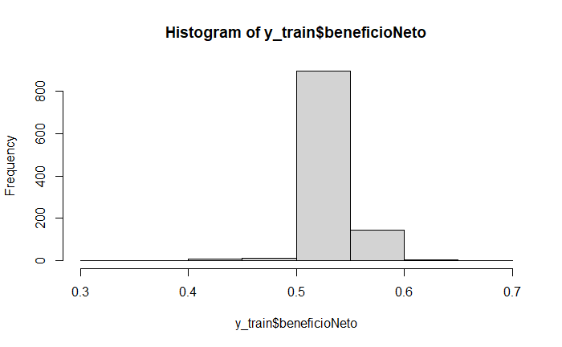

```r
hist(y_train$beneficioNeto, freq = TRUE)
```

Verificamos que la normalización con logaritmo no haya dejanos registros nulos

```r
print(colSums(is.na(y_val)))
```

```
beneficioNeto
            0
```

Graficamos para observar su comportamiento

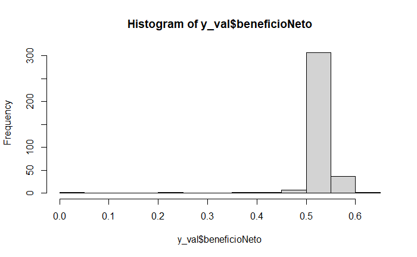

```r
hist(y_val$beneficioNeto, freq = TRUE)
```

Verificamos que la normalización con logaritmo no haya dejanos registros nulos

```r
print(colSums(is.na(y_test)))
```

```
beneficioNeto
            0
```

Graficamos para observar su comportamiento

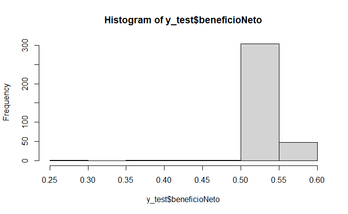

```r
hist(y_test$beneficioNeto, freq = TRUE)
```

```r
df_train <- df_train[ ,!colnames(df_train)=="beneficioNeto"]
df_val <- df_val[ ,!colnames(df_val)=="beneficioNeto"]
df_test <- df_test[ ,!colnames(df_test)=="beneficioNeto"]
```

Verificamos que el dataframe esté correcto

```r
head(df_train)
```

|  | x | ticker_symbol | period_ending | accounts_payable | accounts_receivable | add_l_income_expense_items | after_tax_roe | capital_expenditures | capital_surplus | cash_ratio | cash_and_cash_equivalents | changes_in_inventories | common_stocks | cost_of_revenue | current_ratio | deferred_asset_charges | deferred_liability_charges | depreciation | earnings_before_interest_and_tax | earnings_before_tax | effect_of_exchange_rate | equity_earnings_loss_unconsolidated_subsidiary | fixed_assets | goodwill | gross_margin | gross_profit | income_tax | intangible_assets | interest_expense | … |
| --- | --- | --- | --- | --- | --- | --- | --- | --- | --- | --- | --- | --- | --- | --- | --- | --- | --- | --- | --- | --- | --- | --- | --- | --- | --- | --- | --- | --- | --- | --- |
| 415 | 414 | ctxs | 2015-12-31 | 431215000 | -7226000 | 5945000 | 16 | -160825000 | 4566919000 | 52 | 368518000 | 7.03e+05 | 299000 | 614364000 | 100 | 215196000 | 414314000 | 428892000 | 356030000 | 311877000 | -10313000 | 0 | 373817000 | 1962722000 | 81 | 2661230000 | -7484000 | 283418000 | 44153000 | … |
| 463 | 462 | dhr | 2014-12-31 | 5016500000 | -113400000 | 173200000 | 11 | -580600000 | 4480900000 | 56 | 3005600000 | 4.99e+07 | 7900000 | 9261400000 | 175 | 0 | 0 | 889500000 | 3519800000 | 3400700000 | -205500000 | 0 | 2171900000 | 15673200000 | 52 | 9892600000 | 857600000 | 7059500000 | 119100000 | … |
| 179 | 178 | ayi | 2013-08-31 | 386200000 | -54800000 | 2800000 | 13 | -40600000 | 735500000 | 93 | 359100000 | -6.50e+06 | 500000 | 1251500000 | 237 | 1700000 | 53900000 | 40800000 | 224300000 | 193100000 | -300000 | 0 | 147900000 | 568200000 | 40 | 837600000 | 65700000 | 245100000 | 31200000 | … |
| 526 | 525 | ecl | 2013-12-31 | 1673900000 | -147400000 | 0 | 13 | -625100000 | 4692000000 | 10 | 339200000 | -3.05e+07 | 345100000 | 7161200000 | 135 | 0 | 0 | 816200000 | 1560600000 | 1298300000 | 1900000 | 0 | 2882000000 | 6862900000 | 46 | 6092200000 | 324700000 | 4785300000 | 262300000 | … |
| 195 | 194 | bax | 2012-12-31 | 4409000000 | -41000000 | 155000000 | 34 | -1161000000 | 5769000000 | 69 | 3270000000 | -1.29e+08 | 683000000 | 6802000000 | 195 | 0 | 0 | 712000000 | 2925000000 | 2838000000 | -57000000 | 0 | 6098000000 | 2502000000 | 51 | 7134000000 | 555000000 | 814000000 | 87000000 | … |
| 938 | 937 | ksu | 2015-12-31 | 401500000 | 12000000 | -67600000 | 12 | -832200000 | 947100000 | 18 | 136600000 | -2.62e+07 | 1100000 | 759200000 | 71 | 0 | 1191100000 | 284600000 | 754500000 | 672600000 | 0 | 18300000 | 7705400000 | 0 | 69 | 1659600000 | 187300000 | 0 | 81900000 | … |

Verificamos que el dataframe esté correcto

```r
head(df_val)
```

|  | x | ticker_symbol | period_ending | accounts_payable | accounts_receivable | add_l_income_expense_items | after_tax_roe | capital_expenditures | capital_surplus | cash_ratio | cash_and_cash_equivalents | changes_in_inventories | common_stocks | cost_of_revenue | current_ratio | deferred_asset_charges | deferred_liability_charges | depreciation | earnings_before_interest_and_tax | earnings_before_tax | effect_of_exchange_rate | equity_earnings_loss_unconsolidated_subsidiary | fixed_assets | goodwill | gross_margin | gross_profit | income_tax | intangible_assets | interest_expense | … |
| --- | --- | --- | --- | --- | --- | --- | --- | --- | --- | --- | --- | --- | --- | --- | --- | --- | --- | --- | --- | --- | --- | --- | --- | --- | --- | --- | --- | --- | --- | --- |
| 550 | 549 | emr | 2014-09-30 | 5.98900e+09 | 163000000 | 0 | 22 | -6.510e+08 | 1.610e+08 | 37 | 3.1490e+09 | 1.03e+08 | 4.770e+08 | 9.9710e+09 | 129 | 0.000e+00 | 0.000e+00 | 5.690e+08 | 3.3870e+09 | 3.1910e+09 | -1.00e+08 | 0 | 3.8020e+09 | 7.1820e+09 | 44 | 7.7620e+09 | 9.53e+08 | 1.689e+09 | 1.960e+08 | … |
| 113 | 112 | amp | 2012-12-31 | 1.32400e+09 | -130000000 | 0 | 11 | -1.370e+08 | 6.503e+09 | NA | 4.9090e+09 | 0.00e+00 | 3.000e+06 | 1.8990e+09 | NA | 2.399e+09 | 0.000e+00 | 2.250e+08 | 1.5560e+09 | 1.2380e+09 | 1.00e+07 | 0 | 0.0000e+00 | 0.0000e+00 | 81 | 8.3600e+09 | 3.35e+08 | 0.000e+00 | 3.180e+08 | … |
| 632 | 631 | fdx | 2016-05-31 | 7.97900e+09 | -199000000 | -1000000 | 13 | -4.818e+09 | 2.892e+09 | 44 | 3.5340e+09 | 0.00e+00 | 3.200e+07 | 1.7327e+10 | 150 | 0.000e+00 | 2.122e+09 | 2.631e+09 | 3.0760e+09 | 2.7400e+09 | -1.02e+08 | 0 | 2.4284e+10 | 6.7470e+09 | 66 | 3.3038e+10 | 9.20e+08 | 0.000e+00 | 3.360e+08 | … |
| 845 | 844 | intu | 2014-07-31 | 4.07000e+08 | -5000000 | 31000000 | 29 | -1.040e+08 | 3.558e+09 | 135 | 8.4900e+08 | 0.00e+00 | 3.000e+06 | 6.0300e+08 | 184 | 0.000e+00 | 3.000e+06 | 1.970e+08 | 1.3310e+09 | 1.3000e+09 | -6.00e+06 | 0 | 5.8900e+08 | 1.3230e+09 | 86 | 3.6400e+09 | 4.47e+08 | 1.330e+08 | 3.100e+07 | … |
| 887 | 886 | jpm | 2015-12-31 | 1.77638e+11 | 22664000000 | 0 | 10 | 0.000e+00 | 9.250e+10 | NA | 5.7308e+11 | 0.00e+00 | 4.105e+09 | 0.0000e+00 | NA | 0.000e+00 | 0.000e+00 | 4.940e+09 | 3.8165e+10 | 3.0702e+10 | -2.76e+08 | 0 | 1.4362e+10 | 4.7325e+10 | 100 | 8.9716e+10 | 6.26e+09 | 7.623e+09 | 7.463e+09 | … |
| 85 | 84 | all | 2012-12-31 | 0.00000e+00 | -1685000000 | 18000000 | 11 | -2.850e+08 | 3.162e+09 | NA | 8.0600e+08 | 0.00e+00 | 9.000e+06 | 2.1618e+10 | NA | 3.621e+09 | 5.970e+08 | 3.880e+08 | 3.6790e+09 | 3.3060e+09 | 0.00e+00 | 0 | 9.8900e+08 | 1.2400e+09 | 35 | 1.1697e+10 | 1.00e+09 | 0.000e+00 | 3.730e+08 | … |

Verificamos que el dataframe esté correcto

```r
head(df_test)
```

|  | x | ticker_symbol | period_ending | accounts_payable | accounts_receivable | add_l_income_expense_items | after_tax_roe | capital_expenditures | capital_surplus | cash_ratio | cash_and_cash_equivalents | changes_in_inventories | common_stocks | cost_of_revenue | current_ratio | deferred_asset_charges | deferred_liability_charges | depreciation | earnings_before_interest_and_tax | earnings_before_tax | effect_of_exchange_rate | equity_earnings_loss_unconsolidated_subsidiary | fixed_assets | goodwill | gross_margin | gross_profit | income_tax | intangible_assets | interest_expense | … |
| --- | --- | --- | --- | --- | --- | --- | --- | --- | --- | --- | --- | --- | --- | --- | --- | --- | --- | --- | --- | --- | --- | --- | --- | --- | --- | --- | --- | --- | --- | --- |
| 3 | 2 | aal | 2014-12-31 | 4668000000 | -160000000 | -1.500e+08 | 143 | -5311000000 | 15135000000 | 60 | 1768000000 | 0 | 7.0000e+06 | 15620000000 | 88 | 0.000e+00 | 829000000 | 1342000000 | 4099000000 | 3212000000 | 0 | 0 | 23084000000 | 4091000000 | 63 | 27030000000 | 330000000 | 2240000000 | 887000000 | … |
| 7 | 6 | aap | 2015-01-03 | 3616038000 | -48209000 | 3.092e+06 | 25 | -228446000 | 562945000 | 3 | 104671000 | -227657000 | 7.0000e+03 | 5390248000 | 130 | 0.000e+00 | 446351000 | 284693000 | 854802000 | 781394000 | -4465000 | 0 | 1432030000 | 995426000 | 45 | 4453613000 | 287569000 | 748125000 | 73408000 | … |
| 14 | 13 | abbv | 2013-12-31 | 6448000000 | 681000000 | -5.400e+07 | 92 | -491000000 | 3671000000 | 144 | 9595000000 | -56000000 | 1.6000e+07 | 4581000000 | 259 | 0.000e+00 | 0 | 897000000 | 5610000000 | 5332000000 | -10000000 | 0 | 2298000000 | 6277000000 | 76 | 14209000000 | 1204000000 | 1890000000 | 278000000 | … |
| 15 | 14 | abbv | 2014-12-31 | 6954000000 | -172000000 | -6.510e+08 | 102 | -612000000 | 4194000000 | 74 | 8348000000 | -203000000 | 1.6000e+07 | 4426000000 | 141 | 0.000e+00 | 159000000 | 786000000 | 2760000000 | 2369000000 | -577000000 | 0 | 2485000000 | 5862000000 | 78 | 15534000000 | 595000000 | 1513000000 | 391000000 | … |
| 20 | 19 | abc | 2016-09-30 | 24670159000 | -912724000 | 5.048e+06 | 67 | -464616000 | 4333001000 | 11 | 2741832000 | -1107252000 | 2.7780e+06 | 142577080000 | 90 | 0.000e+00 | 2214774000 | 392166000 | 1530822000 | 1390910000 | 0 | 0 | 1530682000 | 5991497000 | 3 | 4272606000 | -37019000 | 2967849000 | 139912000 | … |
| 21 | 20 | abt | 2012-12-31 | 10889000000 | 36000000 | -1.260e+09 | 22 | -1795000000 | 0 | 114 | 10802000000 | -417000000 | 1.1755e+10 | 8899000000 | 236 | 3.213e+09 | 0 | 2782000000 | 100000000 | -220000000 | 40000000 | 0 | 8063000000 | 15774000000 | 53 | 10151000000 | -457000000 | 8588000000 | 320000000 | … |

Creamos la función para aplicar la regresión lineal

```r
train_linear_regression = function(X,y){
  one = as.vector(rep(1, dim(X)[1])) #Se crea columna ficticia con el dígito 1 para la matriz X y con la misma cantidad de filas de X
  X = cbind(ones, X) #Se añade la columna anteriormente creada a la matriz X

  XTX = t(X) %*% X #Se calcula el producto entre X y XT
  XTX_inv = solve(XTX) #Se calcula la inversa de la matriz X con XTX
  w = XTX_inv %*% t(X) %*% y #Multiplica la inversa de XTX por la matriz transpuesta de X y por el vector de valores objetivo y, para obtener los coeficientes de la regresión lineal

  w #Retorna los elementos calculados
}
```